# PCA From Scratch trên UCI HAR — Giai đoạn 1 đến 11

## AI PROMPTING LOG — P03: PCAFromScratch bằng covariance + eigendecomposition

**Prompt:**

> Viết class `PCAFromScratch` bằng NumPy, không dùng sklearn. Input là dữ liệu đã standardize. Trong `fit(X)`: tính covariance matrix thủ công theo `(X.T @ X)/(n_samples-1)`; dùng `np.linalg.eigh` vì covariance matrix đối xứng; sắp xếp eigenvalues giảm dần và reorder eigenvectors tương ứng; loại sai số eigenvalue âm rất nhỏ do floating point nếu cần; tính `explained_variance_ratio_` và `cumulative_explained_variance_`; lưu `components_` theo convention mỗi cột là một eigenvector. Hỗ trợ `n_components=None` hoặc một số nguyên hợp lệ. Trong `transform(X)`, project bằng `X @ components_`; trong `inverse_transform(Z)` reconstruct bằng `Z @ components_.T`; thêm `fit_transform`. Hãy validate kích thước và không được dùng label y. Code phải đủ tổng quát để chạy với 561 features của UCI HAR.

**Logic cần giữ nguyên:** covariance → `eigh` → descending sort → EVR → choose (W_k) → transform/inverse-transform.

```python
# =========================
# 7. PCA From Scratch
# =========================
class PCAFromScratch:
    def __init__(self, n_components=None, negative_eigen_tol=1e-10):
        self.n_components = n_components
        self.negative_eigen_tol = negative_eigen_tol

        self.n_features_in_ = None
        self.n_components_ = None

        self.covariance_ = None
        self.eigenvalues_all_ = None
        self.eigenvectors_all_ = None

        self.explained_variance_ = None
        self.explained_variance_ratio_ = None
        self.cumulative_explained_variance_ = None

        self.components_ = None
        self.is_fitted_ = False

    def fit(self, X):
        X = np.asarray(X, dtype=np.float64)

        if X.ndim != 2:
            raise ValueError("X phải là ma trận 2D.")

        n_samples, n_features = X.shape
        if n_samples < 2:
            raise ValueError("Cần ít nhất 2 samples để tính covariance.")

        self.n_features_in_ = n_features

        # 1) Covariance matrix
        self.covariance_ = (X.T @ X) / (n_samples - 1)

        # 2) Eigendecomposition cho ma trận đối xứng
        eigenvalues, eigenvectors = np.linalg.eigh(self.covariance_)

        # 3) Sort giảm dần
        order = np.argsort(eigenvalues)[::-1]
        eigenvalues = eigenvalues[order]
        eigenvectors = eigenvectors[:, order]

        # 4) Xử lý sai số floating point rất nhỏ
        if np.min(eigenvalues) < -self.negative_eigen_tol:
            raise ValueError(
                "Phát hiện eigenvalue âm đáng kể; covariance/PCA có thể có lỗi."
            )

        eigenvalues = np.where(
            (eigenvalues < 0) & (np.abs(eigenvalues) <= self.negative_eigen_tol),
            0.0,
            eigenvalues
        )

        self.eigenvalues_all_ = eigenvalues
        self.eigenvectors_all_ = eigenvectors

        total_variance = np.sum(eigenvalues)
        if total_variance <= 0:
            raise ValueError("Tổng variance không dương.")

        explained_ratio_all = eigenvalues / total_variance
        cumulative_all = np.cumsum(explained_ratio_all)

        # 5) Resolve n_components
        if self.n_components is None:
            k = n_features
        else:
            k = int(self.n_components)
            if not (1 <= k <= n_features):
                raise ValueError(
                    f"n_components phải nằm trong [1, {n_features}]."
                )

        self.n_components_ = k

        # Convention: columns = principal axes
        self.components_ = eigenvectors[:, :k]
        self.explained_variance_ = eigenvalues[:k]
        self.explained_variance_ratio_ = explained_ratio_all[:k]
        self.cumulative_explained_variance_ = cumulative_all[:k]

        self.is_fitted_ = True
        return self

    def transform(self, X):
        if not self.is_fitted_:
            raise RuntimeError("PCA chưa được fit.")

        X = np.asarray(X, dtype=np.float64)

        if X.ndim != 2 or X.shape[1] != self.n_features_in_:
            raise ValueError(
                f"X phải có shape (n_samples, {self.n_features_in_})."
            )

        return X @ self.components_

    def fit_transform(self, X):
        return self.fit(X).transform(X)

    def inverse_transform(self, Z):
        if not self.is_fitted_:
            raise RuntimeError("PCA chưa được fit.")

        Z = np.asarray(Z, dtype=np.float64)

        if Z.ndim != 2 or Z.shape[1] != self.n_components_:
            raise ValueError(
                f"Z phải có shape (n_samples, {self.n_components_})."
            )

        return Z @ self.components_.T


# Fit FULL PCA trên TRAIN để phục vụ phân tích variance.
pca_full = PCAFromScratch(n_components=None)
pca_full.fit(X_train_scaled)

print("Covariance shape:", pca_full.covariance_.shape)
print("Eigenvalues shape:", pca_full.eigenvalues_all_.shape)
print("Eigenvectors shape:", pca_full.eigenvectors_all_.shape)
print("Components retained:", pca_full.n_components_)
```

```
Covariance shape: (561, 561)
Eigenvalues shape: (561,)
Eigenvectors shape: (561, 561)
Components retained: 561
```

# Giai đoạn 4 — Kiểm chứng PCA hoạt động đúng

Ta **không dùng sklearn làm oracle**. Thay vào đó kiểm chứng trực tiếp các tính chất toán học:

1. Covariance matrix đối xứng.
2. Eigenvalues không âm (cho phép sai số rất nhỏ).
3. Eigenvectors trực giao.
4. Tổng explained variance ratio ≈ 1.
5. Eigenvalues/variance được sắp xếp giảm dần.
6. Covariance của PCA scores gần đường chéo.
7. Variance của từng PC gần bằng eigenvalue tương ứng.

Nếu các kiểm tra này đạt, implementation PCA được xem là đúng về mặt số học/toán học.

## AI PROMPTING LOG — P04: Mathematical validation cho PCA tự xây dựng

**Prompt:**

> Tôi đã có class PCA tự xây dựng bằng covariance matrix và `np.linalg.eigh`, đã fit trên `X_train_scaled`. Hãy viết bộ validation không dựa vào sklearn gồm: (1) kiểm tra covariance matrix đối xứng bằng max absolute symmetry error; (2) kiểm tra eigenvalues không âm ngoài tolerance; (3) kiểm tra trực giao eigenvectors qua `V.T @ V` so với identity; (4) kiểm tra tổng explained variance ratio gần 1; (5) kiểm tra eigenvalues đã giảm dần; (6) transform toàn bộ train bằng tất cả PCs rồi tính covariance của PCA scores, đo max off-diagonal absolute value để xác nhận các PCs gần không tương quan; (7) so sánh diagonal của score covariance với eigenvalues. In từng metric và assertion với tolerance hợp lý. Không dùng sklearn.

**Logic cần giữ nguyên:** kiểm chứng từ các invariant toán học của PCA, không so sánh với thư viện PCA có sẵn.

```python
# =========================
# 8. Mathematical validation / checkpoint 3
# =========================
def validate_pca_math(pca, X_scaled, tol=1e-8):
    print("=== PCA MATHEMATICAL VALIDATION ===")

    C = pca.covariance_
    V = pca.eigenvectors_all_
    lambdas = pca.eigenvalues_all_

    # 1. Covariance symmetry
    symmetry_error = np.max(np.abs(C - C.T))
    print("1) Max covariance symmetry error:", symmetry_error)

    # 2. Eigenvalue non-negativity
    min_eigenvalue = np.min(lambdas)
    print("2) Minimum eigenvalue:", min_eigenvalue)

    # 3. Orthogonality
    I = np.eye(V.shape[1])
    orthogonality_error = np.max(np.abs(V.T @ V - I))
    print("3) Max eigenvector orthogonality error:", orthogonality_error)

    # 4. Sum explained variance ratio
    evr_all = lambdas / np.sum(lambdas)
    evr_sum = np.sum(evr_all)
    print("4) Sum explained variance ratio:", evr_sum)

    # 5. Descending order
    max_order_violation = np.max(np.diff(lambdas))
    sorted_descending = np.all(np.diff(lambdas) <= tol)
    print("5) Eigenvalues descending:", sorted_descending)
    print("   Max order violation:", max_order_violation)

    # 6. Transform bằng toàn bộ PCs
    Z_full = X_scaled @ V
    cov_Z = (Z_full.T @ Z_full) / (Z_full.shape[0] - 1)

    off_diag = cov_Z - np.diag(np.diag(cov_Z))
    max_off_diag = np.max(np.abs(off_diag))
    print("6) Max |off-diagonal| of PCA-score covariance:", max_off_diag)

    # 7. Diagonal should match eigenvalues
    diag_error = np.max(np.abs(np.diag(cov_Z) - lambdas))
    print("7) Max |diag(cov_Z) - eigenvalue|:", diag_error)

    # Assertions
    assert symmetry_error < tol
    assert min_eigenvalue >= -tol
    assert orthogonality_error < tol
    assert abs(evr_sum - 1.0) < tol
    assert sorted_descending
    assert max_off_diag < 1e-7
    assert diag_error < 1e-7

    metrics = {
        "symmetry_error": symmetry_error,
        "min_eigenvalue": min_eigenvalue,
        "orthogonality_error": orthogonality_error,
        "evr_sum": evr_sum,
        "max_off_diagonal_score_cov": max_off_diag,
        "score_cov_diag_vs_eigen_error": diag_error,
    }

    print("\nCHECKPOINT 3: PASS ✅")
    return metrics


validation_metrics = validate_pca_math(
    pca_full,
    X_train_scaled
)
```

```
=== PCA MATHEMATICAL VALIDATION ===
1) Max covariance symmetry error: 0.0
2) Minimum eigenvalue: 0.0
3) Max eigenvector orthogonality error: 3.552713678800501e-15
4) Sum explained variance ratio: 0.9999999999999999
5) Eigenvalues descending: True
   Max order violation: 0.0
6) Max |off-diagonal| of PCA-score covariance: 1.0692841735916926e-13
7) Max |diag(cov_Z) - eigenvalue|: 1.7053025658242404e-13

CHECKPOINT 3: PASS ✅
```

## AI PROMPTING LOG — P05: Kiểm tra transform và inverse-transform

**Prompt:**

> Dùng class `PCAFromScratch` đã xây dựng để kiểm tra API transform/inverse_transform trên UCI HAR. Chọn thử một giá trị k nhỏ như 10 chỉ để kiểm tra chức năng, fit PCA trên `X_train_scaled`, transform cả train và test, kiểm tra shape đầu ra, reconstruct train bằng inverse_transform và tính reconstruction MSE. Không dùng label để fit PCA. In shape và MSE; thêm assertion để chắc chắn số cột sau transform bằng k, số sample không đổi, và MSE hữu hạn. Đây chỉ là functional test, chưa dùng k=10 để kết luận k tối ưu.

**Logic cần giữ nguyên:** test API và shape trước khi bước vào phân tích lựa chọn số components.

```python
# =========================
# 9. Functional test transform / inverse_transform
# =========================
k_test = 10

pca_test = PCAFromScratch(n_components=k_test)
X_train_pca_test = pca_test.fit_transform(X_train_scaled)
X_test_pca_test = pca_test.transform(X_test_scaled)

X_train_reconstructed_test = pca_test.inverse_transform(X_train_pca_test)
reconstruction_mse_test = np.mean(
    (X_train_scaled - X_train_reconstructed_test) ** 2
)

print("=== PCA FUNCTIONAL TEST ===")
print("k_test:", k_test)
print("Train original:", X_train_scaled.shape)
print("Train PCA     :", X_train_pca_test.shape)
print("Test original :", X_test_scaled.shape)
print("Test PCA      :", X_test_pca_test.shape)
print("Reconstruction MSE (k=10):", reconstruction_mse_test)

assert X_train_pca_test.shape == (X_train_scaled.shape[0], k_test)
assert X_test_pca_test.shape == (X_test_scaled.shape[0], k_test)
assert X_train_reconstructed_test.shape == X_train_scaled.shape
assert np.isfinite(reconstruction_mse_test)

print("\nFUNCTIONAL TEST: PASS ✅")
```

```
=== PCA FUNCTIONAL TEST ===
k_test: 10
Train original: (7352, 561)
Train PCA     : (7352, 10)
Test original : (2947, 561)
Test PCA      : (2947, 10)
Reconstruction MSE (k=10): 0.2918443124130924

FUNCTIONAL TEST: PASS ✅
```

# Tổng kết Giai đoạn 1–4

Sau khi chạy thành công đến đây, ta đã có:

- dữ liệu UCI HAR được kiểm tra;
- train/test được giữ tách biệt;
- standardization tự xây dựng, fit **chỉ trên train**;
- PCA tự xây dựng bằng covariance + eigendecomposition;
- `fit`, `transform`, `fit_transform`, `inverse_transform`;
- bộ kiểm chứng toán học độc lập với sklearn;
- functional test của transform/reconstruction;
- AI PROMPTING LOG đủ chi tiết để tái tạo từng khối xử lý.

## Điều kiện để chuyển sang Giai đoạn 5

Các dòng sau phải xuất hiện:

```
CHECKPOINT 1: PASS
CHECKPOINT 2: PASS
CHECKPOINT 3: PASS
FUNCTIONAL TEST: PASS
```

# Giai đoạn tiếp theo

Sau checkpoint này mới thực hiện:

- Scree Plot;
- Explained Variance Ratio;
- Cumulative Explained Variance;
- tự tìm `k80`, `k90`, `k95`, `k99`;
- 2D/3D PCA visualization;
- reconstruction error theo nhiều k;
- loading analysis;
- lựa chọn số PC cuối cùng.

**Không chọn `n_components` tối ưu trước khi chạy các phân tích trên.**

# Giai đoạn 5 — Phân tích Explained Variance và chọn ngưỡng

Ở giai đoạn này, **không fit lại PCA** và không chọn `k` tùy ý.

Ta sử dụng eigenvalues đã học từ `X_train_scaled` trong `pca_full` để:

1. tính Explained Variance Ratio (EVR);
2. tính Cumulative Explained Variance;
3. vẽ Scree Plot;
4. tìm số Principal Components tối thiểu đạt 80%, 90%, 95%, 99%.

Các ngưỡng này là **candidate**, chưa phải kết luận cuối cùng.

## AI PROMPTING LOG — P06: Explained Variance + threshold selection

**Prompt:**

> Tôi đã có `pca_full` là PCA from scratch fit trên `X_train_scaled`, trong đó `eigenvalues_all_` được sắp xếp giảm dần. Hãy viết code NumPy/Matplotlib, không dùng sklearn, để tính `explained_variance_ratio_all = eigenvalues / sum(eigenvalues)` và `cumulative_variance_all = cumsum(explained_variance_ratio_all)`. Vẽ một Scree Plot của explained variance ratio theo principal component và một biểu đồ cumulative explained variance riêng biệt. Tự tìm số component tối thiểu đạt 80%, 90%, 95%, 99% bằng NumPy, lưu thành dictionary `k_by_threshold`, và hiển thị bảng gồm threshold, số components, variance thực tế giữ lại và phần trăm số chiều được giảm từ 561 features. Thêm assertion rằng cumulative variance không giảm, giá trị cuối gần 1, và các k tăng theo threshold. Không dùng label và không fit PCA trên test.

**Logic cần giữ nguyên:** eigenvalues train → EVR → cumulative EVR → threshold search → compression summary → validation.

```python
# =========================
# 10. Explained Variance Analysis
# =========================
eigenvalues_all = pca_full.eigenvalues_all_

explained_variance_ratio_all = (
    eigenvalues_all / np.sum(eigenvalues_all)
)
cumulative_variance_all = np.cumsum(
    explained_variance_ratio_all
)

print("Số principal components:", len(eigenvalues_all))
print("Tổng EVR:", explained_variance_ratio_all.sum())
print("Cumulative variance cuối:", cumulative_variance_all[-1])

assert np.all(explained_variance_ratio_all >= -1e-12)
assert np.all(np.diff(cumulative_variance_all) >= -1e-12)
assert abs(cumulative_variance_all[-1] - 1.0) < 1e-10

print("Explained variance checks: PASS ✅")
```

```
Số principal components: 561
Tổng EVR: 0.9999999999999999
Cumulative variance cuối: 1.000000000000001
Explained variance checks: PASS ✅
```

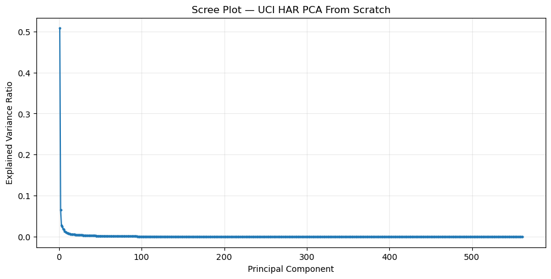

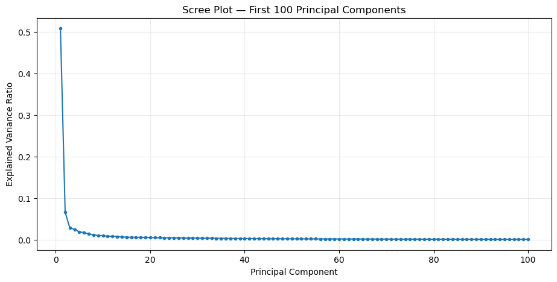

```python
# =========================
# 11. Scree Plot
# =========================
pc_indices = np.arange(1, len(explained_variance_ratio_all) + 1)

plt.figure(figsize=(11, 5))
plt.plot(pc_indices, explained_variance_ratio_all, marker="o", markersize=2)
plt.xlabel("Principal Component")
plt.ylabel("Explained Variance Ratio")
plt.title("Scree Plot — UCI HAR PCA From Scratch")
plt.grid(alpha=0.25)
plt.savefig(FIGURE_DIR / "CP04_scree_plot.png", dpi=150, bbox_inches="tight")
plt.show()

# Zoom 100 PCs đầu để dễ quan sát elbow.
n_zoom = min(100, len(pc_indices))

plt.figure(figsize=(11, 5))
plt.plot(
    pc_indices[:n_zoom],
    explained_variance_ratio_all[:n_zoom],
    marker="o",
    markersize=3
)
plt.xlabel("Principal Component")
plt.ylabel("Explained Variance Ratio")
plt.title(f"Scree Plot — First {n_zoom} Principal Components")
plt.grid(alpha=0.25)
plt.savefig(FIGURE_DIR / "CP04_scree_first100.png", dpi=150, bbox_inches="tight")
plt.show()
```

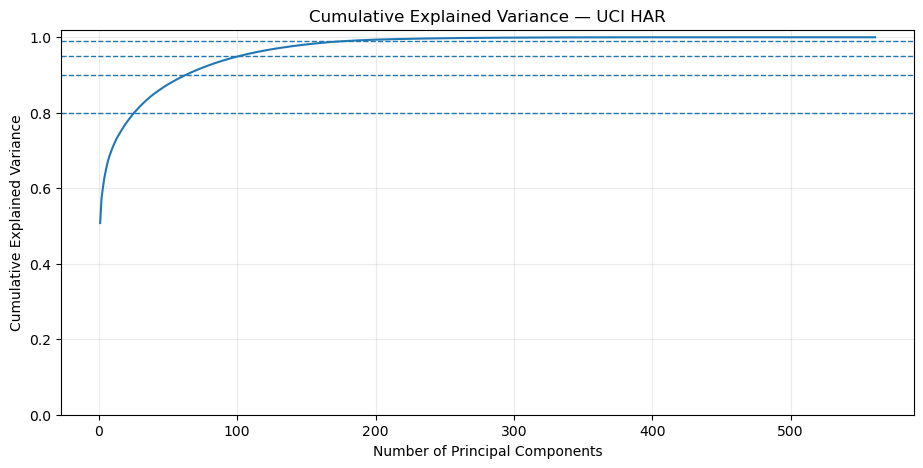

```python
# =========================
# 12. Cumulative Explained Variance
# =========================
plt.figure(figsize=(11, 5))
plt.plot(pc_indices, cumulative_variance_all)
plt.xlabel("Number of Principal Components")
plt.ylabel("Cumulative Explained Variance")
plt.title("Cumulative Explained Variance — UCI HAR")
plt.ylim(0, 1.02)
plt.grid(alpha=0.25)

for threshold in [0.80, 0.90, 0.95, 0.99]:
    plt.axhline(threshold, linestyle="--", linewidth=1)

plt.savefig(FIGURE_DIR / "CP04_cumulative_variance.png", dpi=150, bbox_inches="tight")
plt.show()
```

```python
# =========================
# 13. Tự tìm k80 / k90 / k95 / k99
# =========================
thresholds = [0.80, 0.90, 0.95, 0.99]

k_by_threshold = {}
threshold_rows = []

n_original_features = X_train_scaled.shape[1]

for threshold in thresholds:
    k = int(
        np.searchsorted(
            cumulative_variance_all,
            threshold,
            side="left"
        ) + 1
    )

    retained = float(cumulative_variance_all[k - 1])
    reduction_ratio = 1.0 - (k / n_original_features)

    k_by_threshold[threshold] = k

    threshold_rows.append({
        "Target variance": threshold,
        "Components (k)": k,
        "Actual retained variance": retained,
        "Dimensions reduced": n_original_features - k,
        "Reduction ratio": reduction_ratio,
    })

threshold_df = pd.DataFrame(threshold_rows)

display(threshold_df)

print("\nSelected candidate k values:")
for threshold, k in k_by_threshold.items():
    print(f"{int(threshold*100)}% variance -> k = {k}")

k_values_threshold = list(k_by_threshold.values())
assert all(
    k_values_threshold[i] <= k_values_threshold[i + 1]
    for i in range(len(k_values_threshold) - 1)
)

print("\nCHECKPOINT 4 — Explained Variance: PASS ✅")
```

|  | Target variance | Components (k) | Actual retained variance | Dimensions reduced | Reduction ratio |
| --- | --- | --- | --- | --- | --- |
| 0 | 0.80 | 26 | 0.801805 | 535 | 0.953654 |
| 1 | 0.90 | 63 | 0.900535 | 498 | 0.887701 |
| 2 | 0.95 | 102 | 0.950756 | 459 | 0.818182 |
| 3 | 0.99 | 179 | 0.990193 | 382 | 0.680927 |

```
Selected candidate k values:
80% variance -> k = 26
90% variance -> k = 63
95% variance -> k = 102
99% variance -> k = 179

CHECKPOINT 4 — Explained Variance: PASS ✅
```

# Giai đoạn 6 — Visualization không gian PCA

Mục tiêu:

- quan sát cấu trúc dữ liệu sau projection;
- xem 6 activity phân bố như thế nào;
- chỉ dùng label để **tô nhóm trên biểu đồ**, không dùng label trong quá trình fit PCA.

Ta trực quan:

- PC1 vs PC2;
- PC1 vs PC3;
- PC2 vs PC3;
- PC1–PC2–PC3 3D.

> Lưu ý: overlap trong 2D/3D **không đồng nghĩa PCA thất bại**, vì phần thông tin phân biệt lớp có thể nằm ở các PC cao hơn.

## AI PROMPTING LOG — P07: PCA 2D/3D visualization

**Prompt:**

> Dùng eigenvectors của `pca_full` đã fit trên training data để project `X_train_scaled` sang ít nhất 3 principal components bằng phép nhân ma trận NumPy, không dùng sklearn. Viết các biểu đồ Matplotlib riêng biệt cho PC1-vs-PC2, PC1-vs-PC3, PC2-vs-PC3 và một scatter 3D PC1-PC2-PC3. Dùng `y_train` và `activity_map` chỉ để nhóm các điểm khi visualize, tuyệt đối không dùng label trong fit PCA. Mỗi activity phải có legend rõ ràng. Có thể giảm alpha và kích thước điểm để xử lý overlap. Thêm kiểm tra shape và tính variance thực tế của PC1, PC2, PC3 để xác nhận thứ tự variance giảm dần.

**Logic cần giữ nguyên:** train PCA scores → first 3 PCs → label only for plotting → inspect separability/overlap → variance sanity check.

```python
# =========================
# 14. PCA scores cho visualization
# =========================
V_all = pca_full.eigenvectors_all_

Z_train_full = X_train_scaled @ V_all
Z_train_3d = Z_train_full[:, :3]

print("Z_train_3d shape:", Z_train_3d.shape)

pc_variances = np.var(Z_train_3d, axis=0, ddof=1)
print("Variance PC1-PC3:", pc_variances)

assert Z_train_3d.shape == (X_train_scaled.shape[0], 3)
assert pc_variances[0] >= pc_variances[1] - 1e-10
assert pc_variances[1] >= pc_variances[2] - 1e-10

print("PCA visualization preparation: PASS ✅")
```

```
Z_train_3d shape: (7352, 3)
Variance PC1-PC3: [284.921131  36.922638  15.746252]
PCA visualization preparation: PASS ✅
```

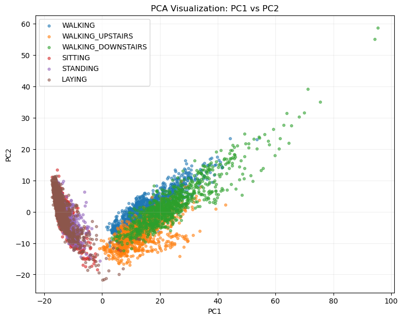

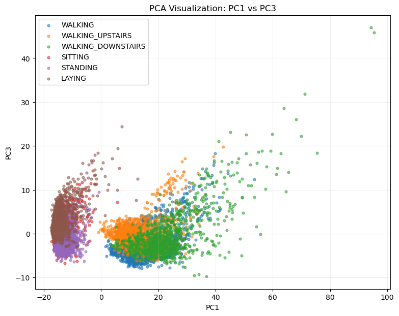

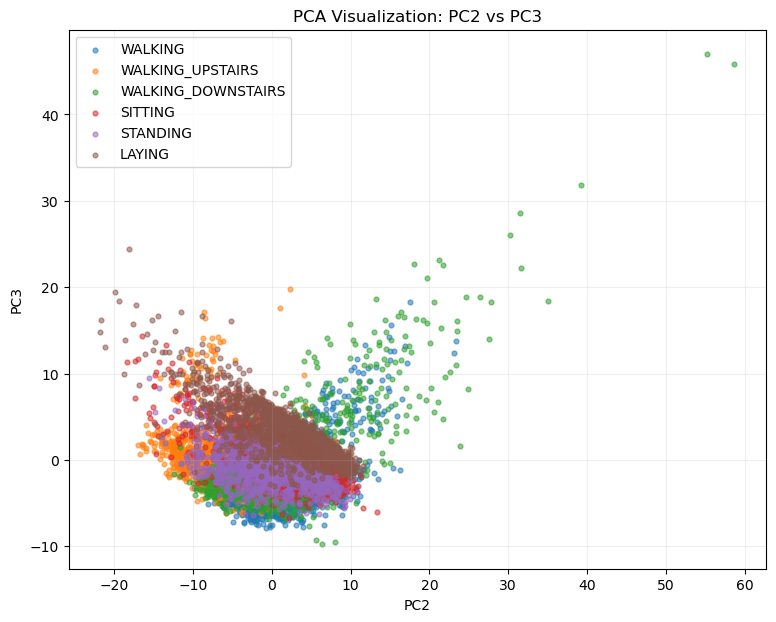

```python
# =========================
# 15. Helper cho scatter 2D
# =========================
def plot_pca_2d(Z, y, activity_map, pc_x, pc_y):
    plt.figure(figsize=(9, 7))

    for label in np.unique(y):
        mask = y == label
        plt.scatter(
            Z[mask, pc_x],
            Z[mask, pc_y],
            s=12,
            alpha=0.55,
            label=activity_map.get(int(label), str(label))
        )

    plt.xlabel(f"PC{pc_x + 1}")
    plt.ylabel(f"PC{pc_y + 1}")
    plt.title(f"PCA Visualization: PC{pc_x + 1} vs PC{pc_y + 1}")
    plt.legend()
    plt.grid(alpha=0.2)
    plt.savefig(FIGURE_DIR / f"CP05_pc{pc_x + 1}_pc{pc_y + 1}.png", dpi=150, bbox_inches="tight")
    plt.show()


plot_pca_2d(Z_train_3d, y_train, activity_map, 0, 1)
plot_pca_2d(Z_train_3d, y_train, activity_map, 0, 2)
plot_pca_2d(Z_train_3d, y_train, activity_map, 1, 2)
```

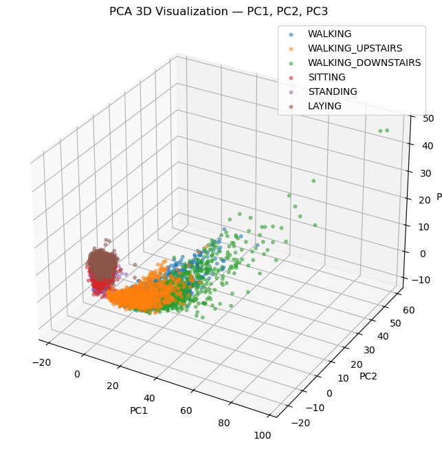

```
CHECKPOINT 5 — PCA Visualization: PASS ✅
```

```python
# =========================
# 16. PCA 3D Visualization
# =========================
fig = plt.figure(figsize=(10, 8))
ax = fig.add_subplot(111, projection="3d")

for label in np.unique(y_train):
    mask = y_train == label

    ax.scatter(
        Z_train_3d[mask, 0],
        Z_train_3d[mask, 1],
        Z_train_3d[mask, 2],
        s=10,
        alpha=0.5,
        label=activity_map.get(int(label), str(label))
    )

ax.set_xlabel("PC1")
ax.set_ylabel("PC2")
ax.set_zlabel("PC3")
ax.set_title("PCA 3D Visualization — PC1, PC2, PC3")
ax.legend()
plt.savefig(FIGURE_DIR / "CP05_pc1_pc2_pc3_3d.png", dpi=150, bbox_inches="tight")
plt.show()

print("CHECKPOINT 5 — PCA Visualization: PASS ✅")
```

# Giai đoạn 7 — Reconstruction Error theo số components

Explained variance cho biết lượng variance giữ lại, nhưng ta cần thêm góc nhìn trực tiếp:

[ Z_k = XW_k ]

[ \hat{X}_k = Z_kW_k^T ]

[ MSE(k)=\frac{1}{np}\sum(X-\hat{X}_k)^2 ]

Ta đánh giá **cả train và test**:

- PCA vẫn chỉ fit trên train;
- test dùng cùng scaler và eigenvectors học từ train;
- khi (k) tăng, reconstruction error phải không tăng.

## AI PROMPTING LOG — P08: Reconstruction error curve

**Prompt:**

> Tôi đã có `X_train_scaled`, `X_test_scaled` và ma trận eigenvectors `V_all` từ PCA fit trên train. Không được fit lại PCA cho từng k. Hãy đánh giá reconstruction error cho một tập các k đại diện như 1,2,3,5,10,20,30,50,75,100,150,200,300,400,500,561 và tự bổ sung các k đạt 80%,90%,95%,99% variance từ `k_by_threshold`. Với mỗi k, lấy `W_k = V_all[:, :k]`, project train/test bằng `X @ W_k`, reconstruct bằng `Z @ W_k.T`, tính MSE riêng cho train và test. Lưu kết quả vào DataFrame và vẽ reconstruction MSE theo k. Kiểm tra MSE hữu hạn và không tăng khi k tăng; ở k = toàn bộ số feature, train reconstruction MSE phải gần 0. Không dùng sklearn.

**Logic cần giữ nguyên:** reuse nested PCA basis → reconstruct train/test for multiple k → MSE curve → monotonic validation → full-basis sanity check.

```python
# =========================
# 17. Reconstruction helpers
# =========================
def project_with_k(X_scaled, V_all, k):
    W_k = V_all[:, :k]
    return X_scaled @ W_k


def reconstruct_with_k(X_scaled, V_all, k):
    W_k = V_all[:, :k]
    Z_k = X_scaled @ W_k
    X_hat = Z_k @ W_k.T
    return X_hat


def reconstruction_mse(X_scaled, X_hat):
    return float(np.mean((X_scaled - X_hat) ** 2))
```

```python
# =========================
# 18. Reconstruction Error Analysis
# =========================
base_k_candidates = [
    1, 2, 3, 5, 10, 20, 30, 50, 75, 100,
    150, 200, 300, 400, 500, n_original_features
]

threshold_k_candidates = list(k_by_threshold.values())

k_candidates = sorted(set(
    k for k in base_k_candidates + threshold_k_candidates
    if 1 <= k <= n_original_features
))

reconstruction_rows = []

for k in k_candidates:
    X_train_hat = reconstruct_with_k(
        X_train_scaled,
        V_all,
        k
    )

    X_test_hat = reconstruct_with_k(
        X_test_scaled,
        V_all,
        k
    )

    train_mse = reconstruction_mse(
        X_train_scaled,
        X_train_hat
    )

    test_mse = reconstruction_mse(
        X_test_scaled,
        X_test_hat
    )

    reconstruction_rows.append({
        "k": k,
        "Train MSE": train_mse,
        "Test MSE": test_mse,
        "Train retained variance": cumulative_variance_all[k - 1],
        "Reduction ratio": 1.0 - (k / n_original_features),
    })

reconstruction_df = pd.DataFrame(reconstruction_rows)

display(reconstruction_df)
```

|  | k | Train MSE | Test MSE | Train retained variance | Reduction ratio |
| --- | --- | --- | --- | --- | --- |
| 0 | 1 | 4.921883e-01 | 4.363483e-01 | 0.507812 | 0.998217 |
| 1 | 2 | 4.263815e-01 | 3.916858e-01 | 0.573619 | 0.996435 |
| 2 | 3 | 3.983171e-01 | 3.735786e-01 | 0.601683 | 0.994652 |
| 3 | 5 | 3.543947e-01 | 3.387090e-01 | 0.645605 | 0.991087 |
| 4 | 10 | 2.918443e-01 | 2.880430e-01 | 0.708156 | 0.982175 |
| 5 | 20 | 2.262535e-01 | 2.266891e-01 | 0.773746 | 0.964349 |
| 6 | 26 | 1.981950e-01 | 2.011244e-01 | 0.801805 | 0.953654 |
| 7 | 30 | 1.822040e-01 | 1.866055e-01 | 0.817796 | 0.946524 |
| 8 | 50 | 1.248164e-01 | 1.324480e-01 | 0.875184 | 0.910873 |
| 9 | 63 | 9.946549e-02 | 1.082636e-01 | 0.900535 | 0.887701 |
| 10 | 75 | 8.045218e-02 | 8.920970e-02 | 0.919548 | 0.866310 |
| 11 | 100 | 5.108496e-02 | 5.783615e-02 | 0.948915 | 0.821747 |
| 12 | 102 | 4.924418e-02 | 5.583215e-02 | 0.950756 | 0.818182 |
| 13 | 150 | 1.894627e-02 | 2.306077e-02 | 0.981054 | 0.732620 |
| 14 | 179 | 9.807321e-03 | 1.242173e-02 | 0.990193 | 0.680927 |
| 15 | 200 | 6.363887e-03 | 8.047198e-03 | 0.993636 | 0.643494 |
| 16 | 300 | 9.012385e-04 | 1.215097e-03 | 0.999099 | 0.465241 |
| 17 | 400 | 2.653673e-05 | 4.680661e-05 | 0.999973 | 0.286988 |
| 18 | 500 | 2.674189e-17 | 3.125249e-17 | 1.000000 | 0.108734 |
| 19 | 561 | 2.571551e-30 | 2.267485e-30 | 1.000000 | 0.000000 |

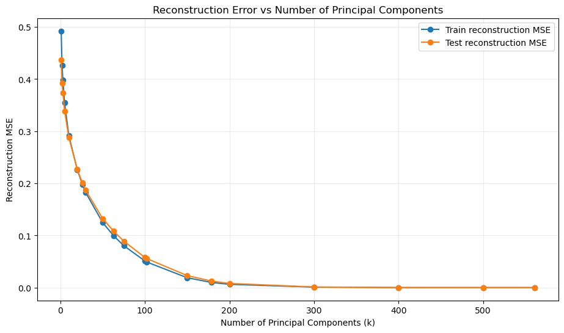

```
Train MSE with all PCs: 2.5715506145949157e-30
Test MSE with all PCs : 2.2674851405482472e-30

CHECKPOINT 6 — Reconstruction Analysis: PASS ✅
```

```python
# =========================
# 19. Reconstruction Error Plot
# =========================
plt.figure(figsize=(11, 6))
plt.plot(
    reconstruction_df["k"],
    reconstruction_df["Train MSE"],
    marker="o",
    label="Train reconstruction MSE"
)
plt.plot(
    reconstruction_df["k"],
    reconstruction_df["Test MSE"],
    marker="o",
    label="Test reconstruction MSE"
)

plt.xlabel("Number of Principal Components (k)")
plt.ylabel("Reconstruction MSE")
plt.title("Reconstruction Error vs Number of Principal Components")
plt.legend()
plt.grid(alpha=0.25)
plt.savefig(FIGURE_DIR / "CP06_reconstruction_curve.png", dpi=150, bbox_inches="tight")
plt.show()

train_mse_values = reconstruction_df["Train MSE"].to_numpy()
test_mse_values = reconstruction_df["Test MSE"].to_numpy()

assert np.all(np.isfinite(train_mse_values))
assert np.all(np.isfinite(test_mse_values))
assert np.all(np.diff(train_mse_values) <= 1e-10)
assert np.all(np.diff(test_mse_values) <= 1e-10)

full_k_row = reconstruction_df[
    reconstruction_df["k"] == n_original_features
].iloc[0]

print("Train MSE with all PCs:", full_k_row["Train MSE"])
print("Test MSE with all PCs :", full_k_row["Test MSE"])

assert full_k_row["Train MSE"] < 1e-20

print("\nCHECKPOINT 6 — Reconstruction Analysis: PASS ✅")
```

# Giai đoạn 8 — Loading Analysis và diễn giải Principal Components

Eigenvector chứa **loading** của các feature gốc trên từng principal component.

Với PC (j), feature có (|loading|) lớn hơn sẽ có đóng góp mạnh hơn vào hướng đó.

Ở đây ta:

1. lấy top features theo (|loading|);
2. giữ cả dấu loading để biết hướng đóng góp;
3. phân tích PC1–PC5;
4. không dùng label.

## AI PROMPTING LOG — P09: Feature loading analysis

**Prompt:**

> Tôi có `V_all` là ma trận eigenvectors PCA from scratch với shape `(n_features, n_features)`, trong đó mỗi cột là một principal component, và `feature_names` chứa tên 561 features UCI HAR. Hãy viết hàm trả về top-N feature có absolute loading lớn nhất cho một PC bất kỳ, bao gồm feature index, feature name, signed loading và absolute loading. Dùng hàm để phân tích PC1 đến PC5, mỗi PC lấy top 10 features. Hiển thị bảng rõ ràng và tạo bar chart riêng cho từng PC. Kiểm tra tổng bình phương loading của mỗi eigenvector gần 1 vì eigenvectors đã normalized. Không dùng sklearn và không dùng label.

**Logic cần giữ nguyên:** eigenvector column → absolute loading rank → preserve sign/name → top-feature interpretation → normalization sanity check.

```python
# =========================
# 20. Loading Analysis
# =========================
def top_loadings_for_pc(
    V_all,
    feature_names,
    pc_index,
    top_n=10
):
    # pc_index dùng zero-based indexing: 0 -> PC1, 1 -> PC2, ...
    loadings = V_all[:, pc_index]

    top_indices = np.argsort(
        np.abs(loadings)
    )[::-1][:top_n]

    rows = []

    for idx in top_indices:
        rows.append({
            "PC": f"PC{pc_index + 1}",
            "Feature index": int(idx),
            "Feature name": feature_names[idx],
            "Loading": float(loadings[idx]),
            "|Loading|": float(abs(loadings[idx])),
        })

    return pd.DataFrame(rows)


loading_tables = {}

for pc_idx in range(5):
    df_pc = top_loadings_for_pc(
        V_all,
        feature_names,
        pc_idx,
        top_n=10
    )

    loading_tables[f"PC{pc_idx + 1}"] = df_pc

    print(f"\n===== TOP LOADINGS — PC{pc_idx + 1} =====")
    display(df_pc)

    norm_sq = float(np.sum(V_all[:, pc_idx] ** 2))
    print(f"Sum of squared loadings PC{pc_idx + 1}: {norm_sq}")

    assert abs(norm_sq - 1.0) < 1e-10

print("\nLoading normalization checks: PASS ✅")
```

```
===== TOP LOADINGS — PC1 =====
```

|  | PC | Feature index | Feature name | Loading | \|Loading\| |
| --- | --- | --- | --- | --- | --- |
| 0 | PC1 | 280 | fBodyAcc-sma() | 0.058571 | 0.058571 |
| 1 | PC1 | 359 | fBodyAccJerk-sma() | 0.058568 | 0.058568 |
| 2 | PC1 | 95 | tBodyAccJerk-sma() | 0.058538 | 0.058538 |
| 3 | PC1 | 438 | fBodyGyro-sma() | 0.058531 | 0.058531 |
| 4 | PC1 | 226 | tBodyAccJerkMag-mean() | 0.058493 | 0.058493 |
| 5 | PC1 | 231 | tBodyAccJerkMag-sma() | 0.058493 | 0.058493 |
| 6 | PC1 | 515 | fBodyBodyAccJerkMag-mean() | 0.058128 | 0.058128 |
| 7 | PC1 | 520 | fBodyBodyAccJerkMag-sma() | 0.058128 | 0.058128 |
| 8 | PC1 | 228 | tBodyAccJerkMag-mad() | 0.058017 | 0.058017 |
| 9 | PC1 | 227 | tBodyAccJerkMag-std() | 0.057985 | 0.057985 |

```
Sum of squared loadings PC1: 0.9999999999999989

===== TOP LOADINGS — PC2 =====
```

|  | PC | Feature index | Feature name | Loading | \|Loading\| |
| --- | --- | --- | --- | --- | --- |
| 0 | PC2 | 295 | fBodyAcc-meanFreq()-Z | 0.122385 | 0.122385 |
| 1 | PC2 | 248 | tBodyGyroMag-arCoeff()1 | 0.119783 | 0.119783 |
| 2 | PC2 | 222 | tGravityAccMag-arCoeff()1 | 0.118162 | 0.118162 |
| 3 | PC2 | 209 | tBodyAccMag-arCoeff()1 | 0.118162 | 0.118162 |
| 4 | PC2 | 512 | fBodyAccMag-meanFreq() | 0.117854 | 0.117854 |
| 5 | PC2 | 73 | tGravityAcc-arCoeff()-Z,1 | 0.117561 | 0.117561 |
| 6 | PC2 | 74 | tGravityAcc-arCoeff()-Z,2 | -0.117093 | 0.117093 |
| 7 | PC2 | 75 | tGravityAcc-arCoeff()-Z,3 | 0.115289 | 0.115289 |
| 8 | PC2 | 76 | tGravityAcc-arCoeff()-Z,4 | -0.112013 | 0.112013 |
| 9 | PC2 | 249 | tBodyGyroMag-arCoeff()2 | -0.111867 | 0.111867 |

```
Sum of squared loadings PC2: 0.9999999999999988

===== TOP LOADINGS — PC3 =====
```

|  | PC | Feature index | Feature name | Loading | \|Loading\| |
| --- | --- | --- | --- | --- | --- |
| 0 | PC3 | 56 | tGravityAcc-energy()-X | -0.110061 | 0.110061 |
| 1 | PC3 | 65 | tGravityAcc-arCoeff()-X,1 | -0.109915 | 0.109915 |
| 2 | PC3 | 63 | tGravityAcc-entropy()-Y | 0.109555 | 0.109555 |
| 3 | PC3 | 58 | tGravityAcc-energy()-Z | 0.109078 | 0.109078 |
| 4 | PC3 | 52 | tGravityAcc-min()-X | -0.108219 | 0.108219 |
| 5 | PC3 | 558 | angle(X,gravityMean) | 0.107508 | 0.107508 |
| 6 | PC3 | 43 | tGravityAcc-std()-X | 0.104384 | 0.104384 |
| 7 | PC3 | 40 | tGravityAcc-mean()-X | -0.104127 | 0.104127 |
| 8 | PC3 | 46 | tGravityAcc-mad()-X | 0.104113 | 0.104113 |
| 9 | PC3 | 59 | tGravityAcc-iqr()-X | 0.102008 | 0.102008 |

```
Sum of squared loadings PC3: 1.0000000000000004

===== TOP LOADINGS — PC4 =====
```

|  | PC | Feature index | Feature name | Loading | \|Loading\| |
| --- | --- | --- | --- | --- | --- |
| 0 | PC4 | 51 | tGravityAcc-max()-Z | -0.143971 | 0.143971 |
| 1 | PC4 | 42 | tGravityAcc-mean()-Z | -0.141018 | 0.141018 |
| 2 | PC4 | 560 | angle(Z,gravityMean) | 0.139935 | 0.139935 |
| 3 | PC4 | 54 | tGravityAcc-min()-Z | -0.136219 | 0.136219 |
| 4 | PC4 | 52 | tGravityAcc-min()-X | 0.127389 | 0.127389 |
| 5 | PC4 | 40 | tGravityAcc-mean()-X | 0.124531 | 0.124531 |
| 6 | PC4 | 296 | fBodyAcc-skewness()-X | -0.123724 | 0.123724 |
| 7 | PC4 | 297 | fBodyAcc-kurtosis()-X | -0.122033 | 0.122033 |
| 8 | PC4 | 56 | tGravityAcc-energy()-X | 0.121121 | 0.121121 |
| 9 | PC4 | 49 | tGravityAcc-max()-X | 0.120072 | 0.120072 |

```
Sum of squared loadings PC4: 1.0000000000000004

===== TOP LOADINGS — PC5 =====
```

|  | PC | Feature index | Feature name | Loading | \|Loading\| |
| --- | --- | --- | --- | --- | --- |
| 0 | PC5 | 558 | angle(X,gravityMean) | 0.167569 | 0.167569 |
| 1 | PC5 | 56 | tGravityAcc-energy()-X | -0.165242 | 0.165242 |
| 2 | PC5 | 49 | tGravityAcc-max()-X | -0.162362 | 0.162362 |
| 3 | PC5 | 40 | tGravityAcc-mean()-X | -0.160478 | 0.160478 |
| 4 | PC5 | 52 | tGravityAcc-min()-X | -0.158584 | 0.158584 |
| 5 | PC5 | 57 | tGravityAcc-energy()-Y | 0.148915 | 0.148915 |
| 6 | PC5 | 71 | tGravityAcc-arCoeff()-Y,3 | 0.140883 | 0.140883 |
| 7 | PC5 | 70 | tGravityAcc-arCoeff()-Y,2 | -0.140379 | 0.140379 |
| 8 | PC5 | 72 | tGravityAcc-arCoeff()-Y,4 | -0.138324 | 0.138324 |
| 9 | PC5 | 69 | tGravityAcc-arCoeff()-Y,1 | 0.137638 | 0.137638 |

```
Sum of squared loadings PC5: 0.9999999999999989

Loading normalization checks: PASS ✅
```

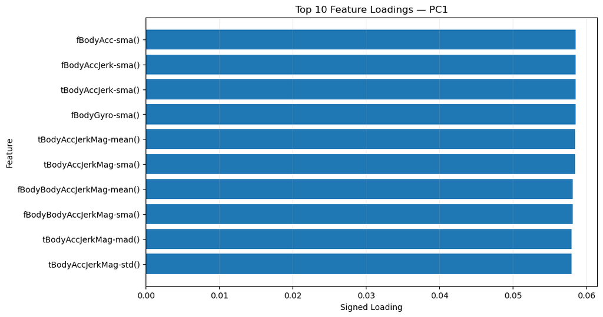

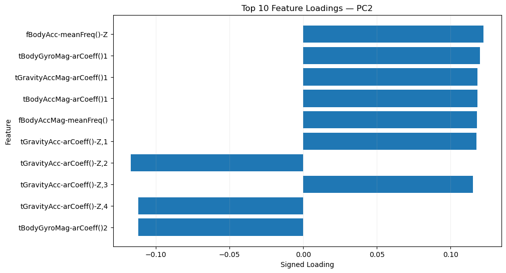

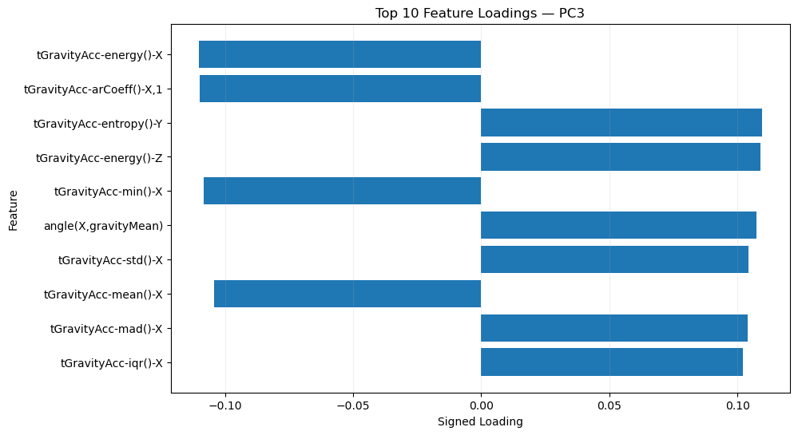

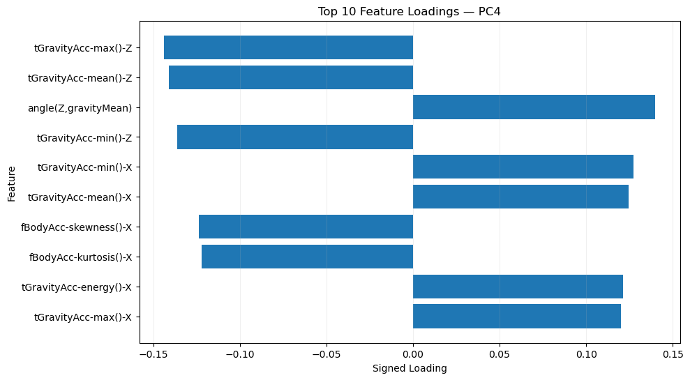

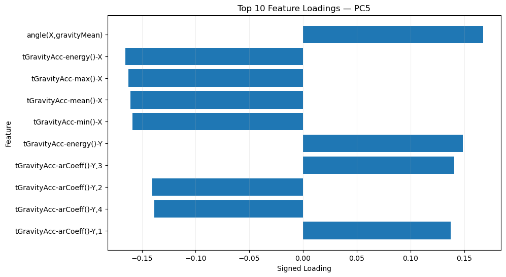

```
CHECKPOINT 7 — Loading Analysis: PASS ✅
```

```python
# =========================
# 21. Loading bar charts — PC1 đến PC5
# =========================
for pc_name, df_pc in loading_tables.items():
    plot_df = df_pc.iloc[::-1]

    plt.figure(figsize=(10, 6))
    plt.barh(
        plot_df["Feature name"],
        plot_df["Loading"]
    )
    plt.xlabel("Signed Loading")
    plt.ylabel("Feature")
    plt.title(f"Top 10 Feature Loadings — {pc_name}")
    plt.grid(axis="x", alpha=0.2)
    plt.savefig(FIGURE_DIR / f"CP07_loadings_{pc_name.lower()}.png", dpi=150, bbox_inches="tight")
    plt.show()

print("CHECKPOINT 7 — Loading Analysis: PASS ✅")
```

# Tổng kết Giai đoạn 5–8

Sau khi chạy thành công, notebook đã có đầy đủ:

## Explained Variance

- Scree Plot;
- cumulative explained variance;
- `k80`, `k90`, `k95`, `k99`;
- tỷ lệ giảm số chiều.

## PCA Visualization

- PC1 vs PC2;
- PC1 vs PC3;
- PC2 vs PC3;
- PC1-PC2-PC3 3D.

## Reconstruction Evaluation

- reconstruction MSE theo nhiều giá trị `k`;
- train MSE;
- test MSE;
- kiểm tra MSE giảm khi số PC tăng.

## Loading Analysis

- top feature đóng góp vào PC1–PC5;
- signed loading;
- absolute loading;
- kiểm tra norm eigenvector.

Sau khi các checkpoint 4–7 đều PASS, có thể chuyển sang **Giai đoạn 9: lựa chọn số Principal Components cuối cùng**, rồi xuất `X_train_pca90`, `X_test_pca90`, `X_train_pca95`, `X_test_pca95` để chuẩn bị cho classification.

# Giai đoạn 9 — Lựa chọn cấu hình PCA cuối cùng

Các checkpoint trước đã xác nhận PCA hoạt động đúng về mặt toán học. Bây giờ ta quyết định **cấu hình nào sẽ được mang sang classification**.

Không nên gọi một giá trị `k` là “tối ưu tuyệt đối” chỉ dựa trên PCA, vì hiệu quả cuối cùng còn phải được xác nhận bằng downstream classifier.

Ta giữ hai cấu hình ứng viên:

- **PCA90**: ưu tiên giảm chiều mạnh hơn.
- **PCA95**: ưu tiên bảo toàn thông tin nhiều hơn.

`PCA95` được dùng làm cấu hình **primary** trước classification; `PCA90` là **compression-oriented alternative**.

## AI PROMPTING LOG — P10: Final PCA candidate selection

**Prompt:**

> Tôi đã chạy PCA from scratch trên UCI HAR và có `k_by_threshold`, `cumulative_variance_all`, `reconstruction_df`, `n_original_features`. Hãy tạo bảng so sánh PCA80, PCA90, PCA95, PCA99 với: target variance, k, actual retained variance, dimensions reduced, reduction ratio, train reconstruction MSE và test reconstruction MSE. Không dùng sklearn. Không tuyên bố một k là tối ưu tuyệt đối trước classification. Đặt PCA95 là cấu hình primary vì ưu tiên bảo toàn thông tin, PCA90 là alternative vì ưu tiên compression. Kiểm tra PCA95 có retained variance >= 0.95, PCA90 >= 0.90 và k90 <= k95. In giải thích ngắn về trade-off.

**Logic cần giữ nguyên:** threshold candidates → reconstruction metrics → trade-off minh bạch → primary/alternative, không overclaim.

```python
# =========================
# 22. Candidate comparison table
# =========================
candidate_rows = []

for threshold in [0.80, 0.90, 0.95, 0.99]:
    k = int(k_by_threshold[threshold])

    rec_match = reconstruction_df[
        reconstruction_df["k"] == k
    ]

    if rec_match.empty:
        X_train_hat = reconstruct_with_k(X_train_scaled, V_all, k)
        X_test_hat = reconstruct_with_k(X_test_scaled, V_all, k)

        train_mse = reconstruction_mse(X_train_scaled, X_train_hat)
        test_mse = reconstruction_mse(X_test_scaled, X_test_hat)
    else:
        train_mse = float(rec_match.iloc[0]["Train MSE"])
        test_mse = float(rec_match.iloc[0]["Test MSE"])

    retained = float(cumulative_variance_all[k - 1])
    reduction_ratio = 1.0 - (k / n_original_features)

    candidate_rows.append({
        "Configuration": f"PCA{int(threshold * 100)}",
        "Target variance": threshold,
        "k": k,
        "Actual retained variance": retained,
        "Dimensions reduced": n_original_features - k,
        "Reduction ratio": reduction_ratio,
        "Train reconstruction MSE": train_mse,
        "Test reconstruction MSE": test_mse,
    })

pca_candidate_df = pd.DataFrame(candidate_rows)
display(pca_candidate_df)

k90 = int(k_by_threshold[0.90])
k95 = int(k_by_threshold[0.95])

assert k90 <= k95
assert cumulative_variance_all[k90 - 1] >= 0.90
assert cumulative_variance_all[k95 - 1] >= 0.95

PRIMARY_CONFIG = "PCA95"
ALTERNATIVE_CONFIG = "PCA90"

print("Primary configuration    :", PRIMARY_CONFIG, f"(k={k95})")
print("Alternative configuration:", ALTERNATIVE_CONFIG, f"(k={k90})")
print()
print("Interpretation:")
print("- PCA95 ưu tiên bảo toàn thông tin trước classification.")
print("- PCA90 ưu tiên giảm chiều mạnh hơn.")
print("- Chưa gọi cấu hình nào là tối ưu tuyệt đối trước downstream evaluation.")

print("\nCHECKPOINT 8 — Candidate Selection: PASS ✅")
```

|  | Configuration | Target variance | k | Actual retained variance | Dimensions reduced | Reduction ratio | Train reconstruction MSE | Test reconstruction MSE |
| --- | --- | --- | --- | --- | --- | --- | --- | --- |
| 0 | PCA80 | 0.80 | 26 | 0.801805 | 535 | 0.953654 | 0.198195 | 0.201124 |
| 1 | PCA90 | 0.90 | 63 | 0.900535 | 498 | 0.887701 | 0.099465 | 0.108264 |
| 2 | PCA95 | 0.95 | 102 | 0.950756 | 459 | 0.818182 | 0.049244 | 0.055832 |
| 3 | PCA99 | 0.99 | 179 | 0.990193 | 382 | 0.680927 | 0.009807 | 0.012422 |

```
Primary configuration    : PCA95 (k=102)
Alternative configuration: PCA90 (k=63)

Interpretation:
- PCA95 ưu tiên bảo toàn thông tin trước classification.
- PCA90 ưu tiên giảm chiều mạnh hơn.
- Chưa gọi cấu hình nào là tối ưu tuyệt đối trước downstream evaluation.

CHECKPOINT 8 — Candidate Selection: PASS ✅
```

# Giai đoạn 10 — Tạo dữ liệu PCA90/PCA95 và kiểm tra cuối

Không fit hai PCA mới độc lập. Dùng lại eigenvectors đã học một lần từ training set:

- `W90 = V_all[:, :k90]`
- `W95 = V_all[:, :k95]`

và project bằng phép nhân ma trận `X @ W`.

## AI PROMPTING LOG — P11: Build PCA90/PCA95 datasets and validate

**Prompt:**

> Tôi có `X_train_scaled`, `X_test_scaled`, `V_all`, `k90`, `k95`, `y_train`, `y_test`. Hãy tạo `X_train_pca90`, `X_test_pca90`, `X_train_pca95`, `X_test_pca95` bằng phép nhân ma trận NumPy với các eigenvector đầu tiên tương ứng; không fit lại PCA và không dùng sklearn. Kiểm tra số sample không đổi, số cột đúng bằng k90/k95, tất cả giá trị hữu hạn, PCA90 phải đúng bằng prefix của PCA95 ở k90 cột đầu trong tolerance, variance từng PC giảm dần và labels không đổi số lượng. Tạo summary DataFrame cho original/PCA90/PCA95 với số chiều, retained variance và reduction ratio.

**Logic cần giữ nguyên:** reuse train-fitted eigenbasis → project train/test → nested-basis consistency → shape/finite/variance checks → summary.

```python
# =========================
# 23. Tạo PCA90 và PCA95
# =========================
W90 = V_all[:, :k90]
W95 = V_all[:, :k95]

X_train_pca90 = X_train_scaled @ W90
X_test_pca90 = X_test_scaled @ W90

X_train_pca95 = X_train_scaled @ W95
X_test_pca95 = X_test_scaled @ W95

print("Original train:", X_train_scaled.shape)
print("PCA90 train   :", X_train_pca90.shape)
print("PCA95 train   :", X_train_pca95.shape)

print()
print("Original test :", X_test_scaled.shape)
print("PCA90 test    :", X_test_pca90.shape)
print("PCA95 test    :", X_test_pca95.shape)
```

```
Original train: (7352, 561)
PCA90 train   : (7352, 63)
PCA95 train   : (7352, 102)

Original test : (2947, 561)
PCA90 test    : (2947, 63)
PCA95 test    : (2947, 102)
```

```python
# =========================
# 24. Final structural validation
# =========================
assert X_train_pca90.shape == (X_train_scaled.shape[0], k90)
assert X_test_pca90.shape == (X_test_scaled.shape[0], k90)
assert X_train_pca95.shape == (X_train_scaled.shape[0], k95)
assert X_test_pca95.shape == (X_test_scaled.shape[0], k95)

for arr in [
    X_train_pca90, X_test_pca90,
    X_train_pca95, X_test_pca95,
]:
    assert np.isfinite(arr).all()

nested_train_error = np.max(
    np.abs(X_train_pca90 - X_train_pca95[:, :k90])
)
nested_test_error = np.max(
    np.abs(X_test_pca90 - X_test_pca95[:, :k90])
)

print("Max nested-basis error — train:", nested_train_error)
print("Max nested-basis error — test :", nested_test_error)

assert nested_train_error < 1e-10
assert nested_test_error < 1e-10

var_pca95_train = np.var(X_train_pca95, axis=0, ddof=1)
assert np.all(np.diff(var_pca95_train) <= 1e-8)

assert len(y_train) == X_train_pca90.shape[0] == X_train_pca95.shape[0]
assert len(y_test) == X_test_pca90.shape[0] == X_test_pca95.shape[0]

print("\nCHECKPOINT 9 — PCA Dataset Validation: PASS ✅")
```

```
Max nested-basis error — train: 4.440892098500626e-15
Max nested-basis error — test : 5.329070518200751e-15

CHECKPOINT 9 — PCA Dataset Validation: PASS ✅
```

```python
# =========================
# 25. Final PCA summary
# =========================
final_summary_df = pd.DataFrame([
    {
        "Dataset representation": "Original standardized",
        "Dimensions": n_original_features,
        "Retained variance": 1.0,
        "Reduction ratio": 0.0,
    },
    {
        "Dataset representation": "PCA90",
        "Dimensions": k90,
        "Retained variance": float(cumulative_variance_all[k90 - 1]),
        "Reduction ratio": 1.0 - (k90 / n_original_features),
    },
    {
        "Dataset representation": "PCA95",
        "Dimensions": k95,
        "Retained variance": float(cumulative_variance_all[k95 - 1]),
        "Reduction ratio": 1.0 - (k95 / n_original_features),
    },
])

display(final_summary_df)

print("Primary candidate    : PCA95")
print("Alternative candidate: PCA90")
print("Baseline             : Original 561 standardized features")
```

|  | Dataset representation | Dimensions | Retained variance | Reduction ratio |
| --- | --- | --- | --- | --- |
| 0 | Original standardized | 561 | 1.000000 | 0.000000 |
| 1 | PCA90 | 63 | 0.900535 | 0.887701 |
| 2 | PCA95 | 102 | 0.950756 | 0.818182 |

```
Primary candidate    : PCA95
Alternative candidate: PCA90
Baseline             : Original 561 standardized features
```

# Giai đoạn 11 — Xuất dữ liệu và tham số PCA cho classification

Để bước classification có thể chạy độc lập, ta lưu:

- `X_train_scaled.npy`, `X_test_scaled.npy`
- `X_train_pca90.npy`, `X_test_pca90.npy`
- `X_train_pca95.npy`, `X_test_pca95.npy`
- `y_train.npy`, `y_test.npy`
- `pca_from_scratch_parameters.npz`
- các bảng đánh giá CSV
- `README.txt`

Nhờ vậy notebook classification sau này không cần fit PCA lại. Các bảng chi tiết và metadata được lưu trong `RUN_DIR/outputs/`; 13 biểu đồ PNG trong `RUN_DIR/figures/`; chỉ số kiểm tra thực tế trong `RUN_DIR/evidence/run_metrics.json`. CP10 chỉ PASS sau khi đọc lại NPY/NPZ và kiểm chứng phép chiếu từ dữ liệu gốc bằng tham số đã lưu.

Có thể đặt biến môi trường `PCA_DATA_ROOT` (thư mục dữ liệu) và `PCA_RUN_DIR` (thư mục kết quả) trước khi chạy notebook.

## AI PROMPTING LOG — P12: Export reproducible PCA artifacts

**Prompt:**

> Tôi đã có pipeline PCA from scratch hoàn chỉnh với `scaler.mean_`, `scaler.scale_`, `pca_full.eigenvalues_all_`, `V_all`, `cumulative_variance_all`, `k90`, `k95`, các ma trận PCA90/PCA95 và labels. Hãy tạo thư mục output trong Colab, lưu arrays thành `.npy`, lưu toàn bộ preprocessing/PCA parameters thành một file `.npz`, và lưu các bảng `pca_candidate_df`, `final_summary_df`, `reconstruction_df` thành CSV. Không dùng sklearn hoặc joblib. Thêm `README.txt` giải thích file nào dùng cho classification, nhấn mạnh PCA chỉ fit trên train và test chỉ được transform. Sau khi lưu, kiểm tra từng file tồn tại và in đường dẫn.

**Logic cần giữ nguyên:** export transformed datasets + labels + train-fitted preprocessing/PCA parameters + evaluation tables + reproducibility note.

```python
# =========================
# 26. Export PCA artifacts
# =========================
OUTPUT_DIR.mkdir(parents=True, exist_ok=True)

# Dataset arrays
np.save(OUTPUT_DIR / "X_train_scaled.npy", X_train_scaled)
np.save(OUTPUT_DIR / "X_test_scaled.npy", X_test_scaled)

np.save(OUTPUT_DIR / "X_train_pca90.npy", X_train_pca90)
np.save(OUTPUT_DIR / "X_test_pca90.npy", X_test_pca90)

np.save(OUTPUT_DIR / "X_train_pca95.npy", X_train_pca95)
np.save(OUTPUT_DIR / "X_test_pca95.npy", X_test_pca95)

np.save(OUTPUT_DIR / "y_train.npy", y_train)
np.save(OUTPUT_DIR / "y_test.npy", y_test)

# PCA/preprocessing parameters
np.savez(
    OUTPUT_DIR / "pca_from_scratch_parameters.npz",
    train_mean=scaler.mean_,
    train_scale=scaler.scale_,
    zero_variance_mask=scaler.zero_variance_mask_,
    eigenvalues=pca_full.eigenvalues_all_,
    eigenvectors=V_all,
    explained_variance_ratio=explained_variance_ratio_all,
    cumulative_variance=cumulative_variance_all,
    k90=np.array(k90),
    k95=np.array(k95),
)

# Evaluation tables
pca_candidate_df.to_csv(
    OUTPUT_DIR / "pca_candidate_comparison.csv",
    index=False
)
final_summary_df.to_csv(
    OUTPUT_DIR / "pca_final_summary.csv",
    index=False
)
reconstruction_df.to_csv(
    OUTPUT_DIR / "pca_reconstruction_analysis.csv",
    index=False
)

readme_lines = [
    "UCI HAR PCA FROM SCRATCH - EXPORTED ARTIFACTS",
    "==============================================",
    "",
    f"Original features: {n_original_features}",
    "",
    "Primary PCA candidate:",
    "- PCA95",
    f"- k = {k95}",
    f"- retained variance = {cumulative_variance_all[k95 - 1]:.8f}",
    "",
    "Alternative PCA candidate:",
    "- PCA90",
    f"- k = {k90}",
    f"- retained variance = {cumulative_variance_all[k90 - 1]:.8f}",
    "",
    "IMPORTANT:",
    "1. Standardization statistics were fitted ONLY on X_train.",
    "2. PCA eigenvectors/eigenvalues were fitted ONLY on X_train_scaled.",
    "3. X_test was only transformed using training-fitted parameters.",
    "4. No sklearn StandardScaler or sklearn PCA was used.",
    "5. For classification compare Original, PCA90, and PCA95.",
]

with open(OUTPUT_DIR / "README.txt", "w", encoding="utf-8") as f:
    f.write("\n".join(readme_lines))

print("Exported files:")
for path in sorted(OUTPUT_DIR.iterdir()):
    print("-", path)

required_files = [
    "X_train_scaled.npy",
    "X_test_scaled.npy",
    "X_train_pca90.npy",
    "X_test_pca90.npy",
    "X_train_pca95.npy",
    "X_test_pca95.npy",
    "y_train.npy",
    "y_test.npy",
    "pca_from_scratch_parameters.npz",
    "pca_candidate_comparison.csv",
    "pca_final_summary.csv",
    "pca_reconstruction_analysis.csv",
    "README.txt",
]

for filename in required_files:
    assert (OUTPUT_DIR / filename).exists()

# Complete numerical tables and metadata for independent inspection.
threshold_df.to_csv(OUTPUT_DIR / "CP04_variance_summary.csv", index=False)
eigenvalue_spectrum_df = pd.DataFrame({
    "PC": np.arange(1, n_original_features + 1),
    "Eigenvalue": eigenvalues_all,
    "Explained variance ratio": explained_variance_ratio_all,
    "Cumulative explained variance": cumulative_variance_all,
})
eigenvalue_spectrum_df.to_csv(OUTPUT_DIR / "CP04_eigenvalue_spectrum.csv", index=False)

feature_metadata_df = pd.DataFrame({
    "feature_index": np.arange(n_original_features),
    "uci_feature_index": np.arange(1, n_original_features + 1),
    "feature_name": feature_names,
})
feature_metadata_df.to_csv(OUTPUT_DIR / "feature_names.csv", index=False)
activity_metadata_df = pd.DataFrame([
    {"label": int(label), "activity": name}
    for label, name in sorted(activity_map.items())
])
activity_metadata_df.to_csv(OUTPUT_DIR / "activity_labels.csv", index=False)
all_loadings_df = pd.concat([
    feature_metadata_df,
    pd.DataFrame(V_all, columns=[f"PC{i + 1}" for i in range(n_original_features)]),
], axis=1)
all_loadings_df.to_csv(OUTPUT_DIR / "CP07_all_loadings.csv", index=False)
for pc_name, table in loading_tables.items():
    table.to_csv(OUTPUT_DIR / f"CP07_top_loadings_{pc_name.lower()}.csv", index=False)

required_files += [
    "CP04_variance_summary.csv",
    "CP04_eigenvalue_spectrum.csv",
    "feature_names.csv",
    "activity_labels.csv",
    "CP07_all_loadings.csv",
] + [f"CP07_top_loadings_pc{i}.csv" for i in range(1, 6)]
required_figures = [
    "CP04_scree_plot.png",
    "CP04_scree_first100.png",
    "CP04_cumulative_variance.png",
    "CP05_pc1_pc2.png",
    "CP05_pc1_pc3.png",
    "CP05_pc2_pc3.png",
    "CP05_pc1_pc2_pc3_3d.png",
    "CP06_reconstruction_curve.png",
] + [f"CP07_loadings_pc{i}.png" for i in range(1, 6)]
for filename in required_files:
    artifact_path = OUTPUT_DIR / filename
    assert artifact_path.is_file() and artifact_path.stat().st_size > 0, filename
for filename in required_figures:
    figure_path = FIGURE_DIR / filename
    assert figure_path.is_file() and figure_path.stat().st_size > 0, filename
    with figure_path.open("rb") as figure_file:
        assert figure_file.read(8) == b"\x89PNG\r\n\x1a\n", filename

# Reload the actual on-disk arrays without pickle and compare every value.
expected_arrays = {
    "X_train_scaled.npy": X_train_scaled,
    "X_test_scaled.npy": X_test_scaled,
    "X_train_pca90.npy": X_train_pca90,
    "X_test_pca90.npy": X_test_pca90,
    "X_train_pca95.npy": X_train_pca95,
    "X_test_pca95.npy": X_test_pca95,
    "y_train.npy": y_train,
    "y_test.npy": y_test,
}
reloaded_arrays = {}
array_checks = {}
for filename, expected in expected_arrays.items():
    actual = np.load(OUTPUT_DIR / filename, allow_pickle=False)
    assert actual.shape == expected.shape, filename
    assert actual.dtype == expected.dtype, filename
    assert np.array_equal(actual, expected), filename
    assert np.isfinite(actual).all(), filename
    reloaded_arrays[filename] = actual
    array_checks[filename] = {
        "shape": list(actual.shape),
        "dtype": str(actual.dtype),
        "exact_match": bool(np.array_equal(actual, expected)),
        "finite": bool(np.isfinite(actual).all()),
    }
```

```python
expected_parameters = {
    "train_mean": scaler.mean_,
    "train_scale": scaler.scale_,
    "zero_variance_mask": scaler.zero_variance_mask_,
    "eigenvalues": pca_full.eigenvalues_all_,
    "eigenvectors": V_all,
    "explained_variance_ratio": explained_variance_ratio_all,
    "cumulative_variance": cumulative_variance_all,
    "k90": np.array(k90),
    "k95": np.array(k95),
}
parameter_checks = {}
with np.load(OUTPUT_DIR / "pca_from_scratch_parameters.npz", allow_pickle=False) as archive:
    assert set(archive.files) == set(expected_parameters)
    saved_parameters = {key: archive[key] for key in archive.files}
for key, expected in expected_parameters.items():
    actual = saved_parameters[key]
    assert actual.shape == expected.shape, key
    assert actual.dtype == expected.dtype, key
    assert np.array_equal(actual, expected), key
    assert np.isfinite(actual).all(), key
    parameter_checks[key] = {
        "shape": list(actual.shape),
        "dtype": str(actual.dtype),
        "exact_match": bool(np.array_equal(actual, expected)),
        "finite": bool(np.isfinite(actual).all()),
    }
assert np.all(saved_parameters["train_scale"] > 0)

# Reproduce all exported representations from RAW inputs and SAVED parameters.
# This checks the complete train/test transform, not just file existence.
projection_errors = {}
for split, raw in [("train", X_train), ("test", X_test)]:
    scaled_from_disk = (raw - saved_parameters["train_mean"]) / saved_parameters["train_scale"]
    scaled_filename = f"X_{split}_scaled.npy"
    saved_scaled = reloaded_arrays[scaled_filename]
    projection_errors[scaled_filename] = float(np.max(np.abs(scaled_from_disk - saved_scaled)))
    assert np.allclose(scaled_from_disk, saved_scaled, rtol=0.0, atol=1e-10), scaled_filename
    for configuration in ["pca90", "pca95"]:
        saved_k = int(saved_parameters["k" + configuration[3:]])
        reproduced = scaled_from_disk @ saved_parameters["eigenvectors"][:, :saved_k]
        filename = f"X_{split}_{configuration}.npy"
        projection_errors[filename] = float(np.max(np.abs(reproduced - reloaded_arrays[filename])))
        assert np.allclose(reproduced, reloaded_arrays[filename], rtol=0.0, atol=1e-10), filename


def finite_summary(array):
    return {
        "finite_count": int(np.isfinite(array).sum()),
        "nan_count": int(np.isnan(array).sum()),
        "inf_count": int(np.isinf(array).sum()),
        "total_count": int(array.size),
    }


def label_counts(labels):
    values, counts = np.unique(labels, return_counts=True)
    return {str(int(label)): int(count) for label, count in zip(values, counts)}


run_metrics = {
    "environment": {
        "python": sys.version,
        "platform": platform.platform(),
        "numpy": np.__version__,
        "pandas": pd.__version__,
        "matplotlib": plt.matplotlib.__version__,
    },
    "dataset": {
        "path": str(DATASET_DIR.resolve()),
        "shapes": {"X_train": list(X_train.shape), "X_test": list(X_test.shape),
                   "y_train": list(y_train.shape), "y_test": list(y_test.shape)},
        "feature_count": len(feature_names),
        "class_counts": {"train": label_counts(y_train), "test": label_counts(y_test)},
        "activity_labels": {str(int(key)): value for key, value in activity_map.items()},
        "finite": {"X_train": finite_summary(X_train), "X_test": finite_summary(X_test)},
        "variance": {"min": float(np.var(X_train, axis=0).min()),
                     "max": float(np.var(X_train, axis=0).max()),
                     "near_zero_count": int((np.var(X_train, axis=0) < 1e-12).sum()),
                     "near_zero_tolerance": 1e-12},
    },
    "standardization": {
        "fit_split": "train",
        "ddof": 0,
        "epsilon": float(scaler.eps),
        "max_abs_mean": float(max_abs_mean),
        "max_std_error": float(max_std_error),
        "zero_variance_count": int(scaler.zero_variance_mask_.sum()),
        "finite": {"train": finite_summary(X_train_scaled), "test": finite_summary(X_test_scaled)},
    },
    "pca_math": {
        **{key: float(value) for key, value in validation_metrics.items()},
        "fit_split": "train",
        "covariance_ddof": 1,
        "covariance_shape": list(pca_full.covariance_.shape),
        "eigenvalues_shape": list(eigenvalues_all.shape),
        "eigenvectors_shape": list(V_all.shape),
        "eigenvalues_descending": bool(np.all(np.diff(eigenvalues_all) <= 1e-8)),
        "max_order_violation": float(np.max(np.diff(eigenvalues_all))),
        "functional_test": {"k": int(k_test),
                            "train_shape": list(X_train_pca_test.shape),
                            "test_shape": list(X_test_pca_test.shape),
                            "train_reconstruction_mse": float(reconstruction_mse_test)},
    },
    "thresholds": {
        str(threshold): {"k": int(k),
                         "retained_variance": float(cumulative_variance_all[k - 1]),
                         "reduction_ratio": float(1.0 - k / n_original_features)}
        for threshold, k in k_by_threshold.items()
    },
    "reconstruction": {
        "space": "standardized features (train-fitted mean and scale)",
        "rows": reconstruction_df.to_dict(orient="records"),
        "full_train_mse": float(full_k_row["Train MSE"]),
        "full_test_mse": float(full_k_row["Test MSE"]),
        "train_monotonic": bool(np.all(np.diff(train_mse_values) <= 1e-10)),
        "test_monotonic": bool(np.all(np.diff(test_mse_values) <= 1e-10)),
    },
    "loading_norms": {f"PC{i + 1}": float(np.sum(V_all[:, i] ** 2)) for i in range(5)},
    "selection": {
        "primary": PRIMARY_CONFIG,
        "alternative": ALTERNATIVE_CONFIG,
        "candidates": pca_candidate_df.to_dict(orient="records"),
        "final_summary": final_summary_df.to_dict(orient="records"),
    },
    "final_validation": {
        "shapes": {name.removesuffix(".npy"): list(array.shape)
                   for name, array in expected_arrays.items()},
        "finite": {name.removesuffix(".npy"): finite_summary(array)
                   for name, array in expected_arrays.items()},
        "nested_train_error": float(nested_train_error),
        "nested_test_error": float(nested_test_error),
        "train_pc_variances_descending": bool(np.all(np.diff(var_pca95_train) <= 1e-8)),
        "train_labels_unchanged": bool(np.array_equal(reloaded_arrays["y_train.npy"], y_train)),
        "test_labels_unchanged": bool(np.array_equal(reloaded_arrays["y_test.npy"], y_test)),
    },
    "export_validation": {
        "array_checks": array_checks,
        "parameter_checks": parameter_checks,
        "projection_errors": projection_errors,
        "projection_atol": 1e-10,
        "projection_rtol": 0.0,
        "required_parameter_keys": list(expected_parameters),
        "required_files": required_files,
        "required_figures": required_figures,
        "passed": True,
    },
}
metrics_path = EVIDENCE_DIR / "run_metrics.json"
metrics_path.write_text(json.dumps(run_metrics, indent=2, ensure_ascii=False, allow_nan=False), encoding="utf-8")
assert json.loads(metrics_path.read_text(encoding="utf-8")) == run_metrics
```

```python
with (OUTPUT_DIR / "README.txt").open("a", encoding="utf-8") as f:
    f.write("\n\nREPRODUCIBILITY EVIDENCE\n")
    f.write("Evaluation tables and feature/activity metadata are in this outputs directory.\n")
    f.write("13 PNG figures are in ../figures; numerical checks are in ../evidence/run_metrics.json.\n")
    f.write("feature_index and Feature index are zero-based; uci_feature_index is one-based.\n")
    f.write("Reconstruction MSE is measured in standardized feature space.\n")
    f.write("NPY/NPZ files were reloaded without pickle and compared exactly to computed arrays.\n")
    f.write("Raw train/test projections using saved parameters passed atol=1e-10, rtol=0.\n")

print("All exported files:")
for filename in required_files:
    print("-", OUTPUT_DIR / filename)
print("Saved figures:", len(required_figures), "in", FIGURE_DIR)
print("Numerical evidence:", metrics_path)
print("Disk reload and raw-input projection checks: PASS")
print("\nCHECKPOINT 10 — Export: PASS ✅")
```

[output not shown]

```
All exported files:
- C:\Users\LENOVO\Desktop\ML_KG\runs\run_20260909T182318Z\outputs\X_train_scaled.npy
- C:\Users\LENOVO\Desktop\ML_KG\runs\run_20260909T182318Z\outputs\X_test_scaled.npy
- C:\Users\LENOVO\Desktop\ML_KG\runs\run_20260909T182318Z\outputs\X_train_pca90.npy
- C:\Users\LENOVO\Desktop\ML_KG\runs\run_20260909T182318Z\outputs\X_test_pca90.npy
- C:\Users\LENOVO\Desktop\ML_KG\runs\run_20260909T182318Z\outputs\X_train_pca95.npy
- C:\Users\LENOVO\Desktop\ML_KG\runs\run_20260909T182318Z\outputs\X_test_pca95.npy
- C:\Users\LENOVO\Desktop\ML_KG\runs\run_20260909T182318Z\outputs\y_train.npy
- C:\Users\LENOVO\Desktop\ML_KG\runs\run_20260909T182318Z\outputs\y_test.npy
- C:\Users\LENOVO\Desktop\ML_KG\runs\run_20260909T182318Z\outputs\pca_from_scratch_parameters.npz
- C:\Users\LENOVO\Desktop\ML_KG\runs\run_20260909T182318Z\outputs\pca_candidate_comparison.csv
- C:\Users\LENOVO\Desktop\ML_KG\runs\run_20260909T182318Z\outputs\pca_final_summary.csv
- C:\Users\LENOVO\Desktop\ML_KG\runs\run_20260909T182318Z\outputs\pca_reconstruction_analysis.csv
- C:\Users\LENOVO\Desktop\ML_KG\runs\run_20260909T182318Z\outputs\README.txt
- C:\Users\LENOVO\Desktop\ML_KG\runs\run_20260909T182318Z\outputs\CP04_variance_summary.csv
- C:\Users\LENOVO\Desktop\ML_KG\runs\run_20260909T182318Z\outputs\CP04_eigenvalue_spectrum.csv
- C:\Users\LENOVO\Desktop\ML_KG\runs\run_20260909T182318Z\outputs\feature_names.csv
- C:\Users\LENOVO\Desktop\ML_KG\runs\run_20260909T182318Z\outputs\activity_labels.csv
- C:\Users\LENOVO\Desktop\ML_KG\runs\run_20260909T182318Z\outputs\CP07_all_loadings.csv
- C:\Users\LENOVO\Desktop\ML_KG\runs\run_20260909T182318Z\outputs\CP07_top_loadings_pc1.csv
- C:\Users\LENOVO\Desktop\ML_KG\runs\run_20260909T182318Z\outputs\CP07_top_loadings_pc2.csv
- C:\Users\LENOVO\Desktop\ML_KG\runs\run_20260909T182318Z\outputs\CP07_top_loadings_pc3.csv
- C:\Users\LENOVO\Desktop\ML_KG\runs\run_20260909T182318Z\outputs\CP07_top_loadings_pc4.csv
- C:\Users\LENOVO\Desktop\ML_KG\runs\run_20260909T182318Z\outputs\CP07_top_loadings_pc5.csv
Saved figures: 13 in C:\Users\LENOVO\Desktop\ML_KG\runs\run_20260909T182318Z\figures
Numerical evidence: C:\Users\LENOVO\Desktop\ML_KG\runs\run_20260909T182318Z\evidence\run_metrics.json
Disk reload and raw-input projection checks: PASS

CHECKPOINT 10 — Export: PASS ✅
```

# Final PCA Completion Check

Nếu notebook chạy đến đây và có:

```
CHECKPOINT 8 — Candidate Selection: PASS
CHECKPOINT 9 — PCA Dataset Validation: PASS
CHECKPOINT 10 — Export: PASS
```

thì phần **PCA From Scratch** đã hoàn tất về:

- preprocessing;
- implementation;
- mathematical validation;
- explained variance;
- visualization;
- reconstruction analysis;
- loading interpretation;
- component selection;
- downstream dataset generation;
- reproducible export.

## Trạng thái cuối trước Classification

Giữ 3 representation để so sánh:

1. **Original standardized — 561 dimensions**
2. **PCA90 — compression-oriented**
3. **PCA95 — information-preserving primary candidate**

Classification ở bước tiếp theo phải giữ **nguyên train/test split gốc**.

Câu hỏi thực nghiệm tiếp theo:

> PCA giảm được bao nhiêu chiều của UCI HAR mà vẫn duy trì được khả năng phân loại hoạt động con người?